# Exploring your harvested data

In this notebook we'll look at some ways of exploring the `results.csv` created by the Trove Newspaper and Gazette Harvester.

```python
import os
import zipfile
from operator import itemgetter
from pathlib import Path

import altair as alt
import nltk
import pandas as pd
from textblob import TextBlob
from wordcloud import WordCloud

nltk.download("stopwords")
nltk.download("punkt")

stopwords = nltk.corpus.stopwords.words("english")
```

```python
%%capture
# Load variables from the .env file if it exists
# Use %%capture to suppress messages
%load_ext dotenv
%dotenv
```

## Loading the data

By default, this notebook will look for existing harvests in the `data` directory. If you want to use a harvest that downloaded previously, just upload the zipped harvest to the `data` directory and run the cell below. It will expand all the zipped files in the `data` directory.

```python
# Import a harvest zip file you've created previously
# First upload the zip file to the data directory, then run this cell

for zipped in Path("data").glob("*.zip"):
    with zipfile.ZipFile(zipped, "r") as zip_file:
        zip_file.extractall(Path("data", zipped.name[:-4]))
```

These functions open up a harvest and convert the `results.csv` into a dataframe for analysis.

```python
def get_latest_harvest():
    """
    Get the timestamp of the most recent harvest.
    """
    harvests = sorted(
        [d for d in os.listdir("data") if os.path.isdir(os.path.join("data", d))]
    )
    return harvests[-1]


def open_harvest_data(timestamp=None):
    """
    Open the results of the specified harvest (most recent by default).

    Returns a DataFrame.
    """
    if not timestamp:
        timestamp = get_latest_harvest()
    df = pd.read_csv(
        os.path.join("data", timestamp, "results.csv"), parse_dates=["date"]
    )
    return df
```

Running `open_harvest_data()` without any parameters will load the most recent harvest. To load a different harvest, just supply the name of the directory containing the harvest (this will generally be a timestamp).

```python
# In testing environment, open a test harvest
if os.getenv("GW_STATUS") == "dev":
    df = open_harvest_data("1655952487")
# Otherwise open most recent harvest
# Supply a harvest directory name to open a specific harvest
else:
    df = open_harvest_data()
```

## Examining the data

Let's have a peek at the dataset.

```python
# .head() displays the first 5 rows of a dataframe
df.head()
```

|  | article_id | title | newspaper_id | newspaper_title | page | date | category | words | illustrated | corrections | snippet | url | page_url |
| --- | --- | --- | --- | --- | --- | --- | --- | --- | --- | --- | --- | --- | --- |
| 0 | 100249640 | MR. WRAGGE'S PREDICTION. | 422 | Forbes Times (NSW : 1899 - 1902; 1912 - 1920) | 2 | 1912-02-07 | Article | 30 | N | 0 | Mr. Wragge forecasts that until 1915 or 1916 t... | https://nla.gov.au/nla.news-article100249640 | http://trove.nla.gov.au/newspaper/page/10517407 |
| 1 | 100252268 | The "Forbes Times." SATURDAY, JUNE 22nd, 1912.... | 422 | Forbes Times (NSW : 1899 - 1902; 1912 - 1920) | 4 | 1912-06-22 | Article | 952 | N | 0 | it has been said that we Australians are the m... | https://nla.gov.au/nla.news-article100252268 | http://trove.nla.gov.au/newspaper/page/10517639 |
| 2 | 100499840 | WRAGGE'S ALMANAC. | 367 | Goulburn Herald (NSW : 1881 - 1907) | 2 | 1902-01-03 | Article | 82 | N | 0 | WE have received from the agents, Messrs. Gord... | https://nla.gov.au/nla.news-article100499840 | http://trove.nla.gov.au/newspaper/page/9423791 |
| 3 | 100503988 | GENERAL NEWS. | 367 | Goulburn Herald (NSW : 1881 - 1907) | 2 | 1902-09-05 | Article | 1043 | N | 1 | At the technological examination in May, last ... | https://nla.gov.au/nla.news-article100503988 | http://trove.nla.gov.au/newspaper/page/9424299 |
| 4 | 100621725 | WEATHER PROPHECIES. | 436 | The Albury Banner and Wodonga Express (NSW : 1... | 28 | 1903-02-13 | Article | 158 | N | 0 | Mr. Wragge has given reasons for prophesying t... | https://nla.gov.au/nla.news-article100621725 | http://trove.nla.gov.au/newspaper/page/10848554 |

How many articles did we harvest?

```python
df.shape[0]
```

```
3066
```

What's the earliest and latest publication date in the dataset?

```python
df["date"].min()
```

```
Timestamp('1854-10-05 00:00:00')
```

```python
df["date"].max()
```

```
Timestamp('1988-02-28 00:00:00')
```

How many different newspapers are represented in our dataset?

```python
len(df["newspaper_id"].unique())
```

```
412
```

Which article has the most words?

```python
df.loc[df["words"].idxmax()]
```

```
article_id                                               18381792
title                                                 Advertising
newspaper_id                                                   35
newspaper_title     The Sydney Morning Herald (NSW : 1842 - 1954)
page                                                           14
date                                          1953-08-22 00:00:00
category                                              Advertising
words                                                      150533
illustrated                                                     N
corrections                                                   242
snippet                                                       NaN
url                   https://nla.gov.au/nla.news-article18381792
page_url           http://trove.nla.gov.au/newspaper/page/1062896
Name: 1359, dtype: object
```

## Show the most common newspapers

Here we'll visualise the 25 most common newspapers in the dataset.

```python
df_newspapers = (
    df.value_counts(["newspaper_title", "newspaper_id"]).to_frame().reset_index()
)
df_newspapers.columns = ["newspaper_title", "newspaper_id", "count"]
df_newspapers
```

|  | newspaper_title | newspaper_id | count |
| --- | --- | --- | --- |
| 0 | The Telegraph (Brisbane, Qld. : 1872 - 1947) | 840 | 272 |
| 1 | The Sydney Morning Herald (NSW : 1842 - 1954) | 35 | 164 |
| 2 | The Mercury (Hobart, Tas. : 1860 - 1954) | 10 | 137 |
| 3 | The Brisbane Courier (Qld. : 1864 - 1933) | 16 | 119 |
| 4 | The Argus (Melbourne, Vic. : 1848 - 1957) | 13 | 74 |
| ... | ... | ... | ... |
| 407 | Ballidu-Wongan Budget (WA : 1927 - 1941) | 1395 | 1 |
| 408 | Wickepin Argus (WA : 1910 - 1934) | 820 | 1 |
| 409 | Avon Argus and Cunderdin-Meckering-Tammin Mail... | 1394 | 1 |
| 410 | Avoca Mail (Vic. : 1863 - 1900; 1915 - 1918) | 756 | 1 |
| 411 | World (Hobart, Tas. : 1918 - 1924) | 861 | 1 |

412 rows × 3 columns

```python
alt.Chart(df_newspapers[:25]).mark_bar().encode(
    x=alt.X("count:Q", title="Number of articles"),
    y=alt.Y("newspaper_title:N", title="Newspaper", sort="-x"),
    tooltip=[
        alt.Tooltip("newspaper_title:N", title="Newspaper"),
        alt.Tooltip("count:Q", title="Articles"),
    ],
)
```

[interactive chart not shown]

## Show when the articles were published

```python
df["year"] = df["date"].dt.year
df_years = df["year"].value_counts().to_frame().reset_index()
df_years.columns = ["year", "count"]
df_years
```

|  | year | count |
| --- | --- | --- |
| 0 | 1902 | 984 |
| 1 | 1903 | 443 |
| 2 | 1914 | 104 |
| 3 | 1912 | 89 |
| 4 | 1913 | 78 |
| ... | ... | ... |
| 83 | 1855 | 1 |
| 84 | 1864 | 1 |
| 85 | 1865 | 1 |
| 86 | 1866 | 1 |
| 87 | 1871 | 1 |

88 rows × 2 columns

```python
alt.Chart(df_years).mark_line().encode(
    x=alt.X("year:Q", axis=alt.Axis(format="d")),
    y=alt.Y("count:Q"),
    tooltip=[
        alt.Tooltip("year", title="Year"),
        alt.Tooltip("count", title="Articles", format=",d"),
    ],
).properties(width=700)
```

[interactive chart not shown]

## Make a simple word cloud from the article titles

```python
df_titles = df.loc[(df["title"] != "No Title") & (df["title"] != "Advertising")]
# Get all the articles titles and turn them into a single string
title_text = df_titles["title"].str.lower().str.cat(sep=" ")
```

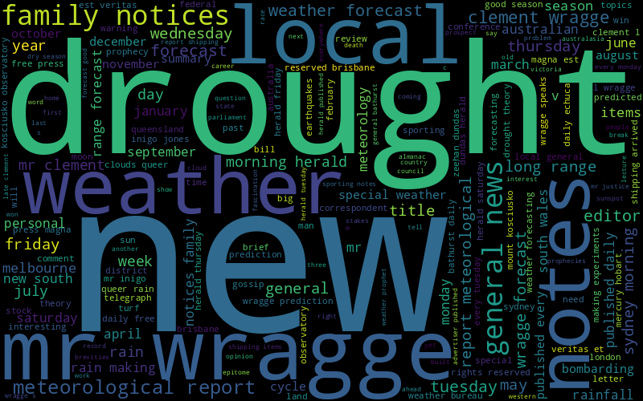

```python
# Generate a word cloud image
wordcloud = WordCloud(width=800, height=500, collocations=True).generate(title_text)
wordcloud.to_image()
```

## Using TextBlob

```python
blob = TextBlob(title_text)
```

```python
word_counts = [
    [word, count]
    for word, count in blob.lower().word_counts.items()
    if word not in stopwords
]
word_counts = sorted(word_counts, key=itemgetter(1), reverse=True)[:25]
pd.DataFrame(word_counts, columns=["word", "count"]).style.format(
    {"count": "{:,}"}
).bar(subset=["count"], color="#d65f5f").set_properties(
    subset=["count"], **{"width": "300px"}
)
```

|  | word | count |
| --- | --- | --- |
| 0 | wragge | 270 |
| 1 | news | 213 |
| 2 | weather | 201 |
| 3 | mr | 193 |
| 4 | 1902 | 188 |
| 5 | general | 146 |
| 6 | forecast | 127 |
| 7 | local | 111 |
| 8 | notes | 100 |
| 9 | drought | 94 |
| 10 | meteorological | 88 |
| 11 | family | 79 |
| 12 | notices | 79 |
| 13 | report | 78 |
| 14 | sydney | 77 |
| 15 | clement | 76 |
| 16 | tuesday | 76 |
| 17 | friday | 71 |
| 18 | herald | 68 |
| 19 | published | 61 |
| 20 | thursday | 60 |
| 21 | editor | 52 |
| 22 | may | 51 |
| 23 | wednesday | 51 |
| 24 | morning | 50 |

## Mapping newspaper locations

This makes use of a spreadsheet file that maps Trove newspaper titles to locations. Once we've loaded the spreadsheet we can use it to locate all of the harvested articles.

```python
# Url of the Trove places spreadshseet
trove_places = "https://docs.google.com/spreadsheets/d/1rURriHBSf3MocI8wsdl1114t0YeyU0BVSXWeg232MZs/gviz/tq?tqx=out:csv&sheet=198244298"

# Open the CSV file with Pandas
place_df = pd.read_csv(trove_places)
```

```python
df_located = pd.merge(
    df_newspapers, place_df, how="left", left_on="newspaper_id", right_on="title_id"
)

# There may be some newspapers that haven't been added to the locations dataset yet, so we'll drop them
df_located.dropna(axis=0, subset=["latitude"], inplace=True)
```

```python
# Load Australian boundaries
australia = alt.topo_feature(
    "https://raw.githubusercontent.com/GLAM-Workbench/trove-newspapers/master/data/aus_state.geojson",
    feature="features",
)

# Create the map of Australia using the boundaries
aus_background = (
    alt.Chart(australia)
    .mark_geoshape(
        # Style the map
        fill="lightgray",
        stroke="white",
    )
    .project("equirectangular")
    .properties(width=600, height=600)
)

# Plot the places
points = (
    alt.Chart(df_located)
    .mark_circle(color="steelblue")
    .encode(
        # Set position of each place using lat and lon
        longitude="longitude:Q",
        latitude="latitude:Q",
        size=alt.Size(
            "count:Q",
            scale=alt.Scale(range=[0, 1000]),
            legend=alt.Legend(title="Number of articles"),
        ),
        # More details on hover
        tooltip=[
            alt.Tooltip("newspaper_title_x", title="Newspaper"),
            "latitude",
            "longitude",
            "count",
        ],
    )
    .properties(width=600, height=600)
)

# Combine map and points
alt.layer(aus_background, points)
```

[interactive chart not shown]

Created by [Tim Sherratt](https://timsherratt.org) ([@wragge](https://twitter.com/wragge)) for the [GLAM Workbench](https://github.com/glam-workbench/).  
Support this project by [becoming a GitHub sponsor](https://github.com/sponsors/wragge?o=esb).